# Mismediation

John Flournoy

12/27/2017

How often do you see evidence for mediation from a statistical test when in fact the data generating process is purely correlational?

## Generating the data

```r
library(lavaan)
library(simsem)
library(semPlot)
```

The data generating model specifies three variables over 3 waves. Each is correlated with the other at r = .5, and fairly stable, with an autoregressive path-weight of .7.

```r
generatingModel <- '

#2 on 1
y2 ~ .7*y1
x2 ~ .7*x1
z2 ~ .7*z1
y2 ~ 0*x1 + 0*z1
x2 ~ 0*y1 + 0*z1
z2 ~ 0*y1 + 0*x1

#3 on 2
y3 ~ .7*y2
x3 ~ .7*x2
z3 ~ .7*z2
y3 ~ 0*x2 + 0*z2
x3 ~ 0*y2 + 0*z2
z3 ~ 0*y2 + 0*x2

#wave cors
y1 ~~ .5*x1 + .5*z1
x1 ~~ .5*z1
y2 ~~ .5*x2 + .5*z2
x2 ~~ .5*z2
y3 ~~ .5*x3 + .5*z3
x3 ~~ .5*z3

#Resid
y1 ~~ 1*y1
x1 ~~ 1*x1
z1 ~~ 1*z1
y2 ~~ 1*y2
x2 ~~ 1*x2
z2 ~~ 1*z2
y3 ~~ 1*y3
x3 ~~ 1*x3
z3 ~~ 1*z3
'

generatingModelEst <- '

#2 on 1
y2 ~ y1
x2 ~ x1
z2 ~ z1
y2 ~ x1 + z1
x2 ~ y1 + z1
z2 ~ y1 + x1

#3 on 2
y3 ~ y2
x3 ~ x2
z3 ~ z2
y3 ~ x2 + z2
x3 ~ y2 + z2
z3 ~ y2 + x2

#wave cors
y1 ~~ x1 + z1
x1 ~~ z1
y2 ~~ x2 + z2
x2 ~~ z2
y3 ~~ x3 + z3
x3 ~~ z3

#Resid
y1 ~~ y1
x1 ~~ x1
z1 ~~ z1
y2 ~~ y2
x2 ~~ x2
z2 ~~ z2
y3 ~~ y3
x3 ~~ x3
z3 ~~ z3
'
```

## Misspecified statistical models

Looking for mediation when the null of no mediation is true can be thought of as estimating a misspecified model. I’m going to concentrate just on the significance of the parameter that estimates the mediated effect, since this is often what people do (rarely is model comparison used, and in cross-sectional data it can be shown that a mediation model is just-identified anyway).

We can check out a few misspecifications. First, we’ll test the best case scenario short of testing the true model. In `mediationModelControlzT1` we do the usual longitudinal best-practice of regressing our wave 2 dependent variable on its wave 1 measurement (`y2 ~ y1 + c*x1 + b*z2`, where `c` and `b` are just the typical labels of the direct paths between the predictor and outcome, and mediator and outcome). In the regression of our wave 2 mediator on the independent variable, we can also include the mediator’s wave 1 measurement (`z2 ~ a*x1 + z1`, where `a` is just the typical label of the path from predictor to mediator). Conceptually, we’ve made sure to account for stability within each variable over time – cross-sectional models of mediation don’t do this.

In the two other misspecified models, we additionally leave out the measurement of the mediator at wave 1, and then also leave out the measurement of the dependent variable at wave 1. We can also look at the cross-sectional mediation model, and a longitudinal mediational model written without any information about previous measurement.

```r
#Each of these does not correctly capture the data generating model specified previously
mediationModelControlzT1 <- ' #2-wave model accounting for prior levels
y2 ~ y1 + c*x1 + b*z2
z2 ~ a*x1 + z1
# indirect effect (a*b)
ab := a*b
# total effect
total := c + (a*b)
'
mediationModelNoControlzT1 <- '#2-wave model, no control for mediator previous level
y2 ~ y1 + c*x1 + b*z2
z2 ~ a*x1
# indirect effect (a*b)
ab := a*b
# total effect
total := c + (a*b)
'
mediationModelNoControlzOryT1 <- '#2-wave, no control for mediator or outcome previous level
y2 ~ c*x1 + b*z2
z2 ~ a*x1
# indirect effect (a*b)
ab := a*b
# total effect
total := c + (a*b)
'
mediationModelCrossSection <- '#Cross sectional mediation
y3 ~ c*x3 + b*z3
z3 ~ a*x3
#indirect
ab := a*b
#total
total := c + (a*b)'

mediationBadLong <- '#3-wave, no control for mediator or outcome previous level
y3 ~ c*x1 + b*z2
z2 ~ a*x1
#indirect
ab := a*b
#total
total := c + (a*b)'
```

Before running a buch of simulations, I’ll make sure the models are as expected by generating a single set, and fitting the above. I won’t show the output because it’s rather lengthy.

```r
someData <- simulateData(model=generatingModel, sample.nobs=250, empirical=T)
fit.DGM <- sem(generatingModelEst, someData, fixed.x=F)
summary(fit.DGM, standardized=T)

fit.CtrlT1.yz <- sem(mediationModelControlzT1, someData)
summary(fit.CtrlT1.yz, standardized = T)

fit.noCtrlT1.z <- sem(mediationModelNoControlzT1, someData)
summary(fit.noCtrlT1.z, standardized = T)

fit.noCtrlT1.yz <- sem(mediationModelNoControlzOryT1, someData)
summary(fit.noCtrlT1.yz, standardized = T)

fit.CrossSection <- sem(mediationModelCrossSection, someData)
summary(fit.CrossSection, standardized = T)

fit.BadLong <- sem(mediationBadLong, someData)
summary(fit.BadLong, standardized = T)
```

## Model path diagrams

First, the data generating model:

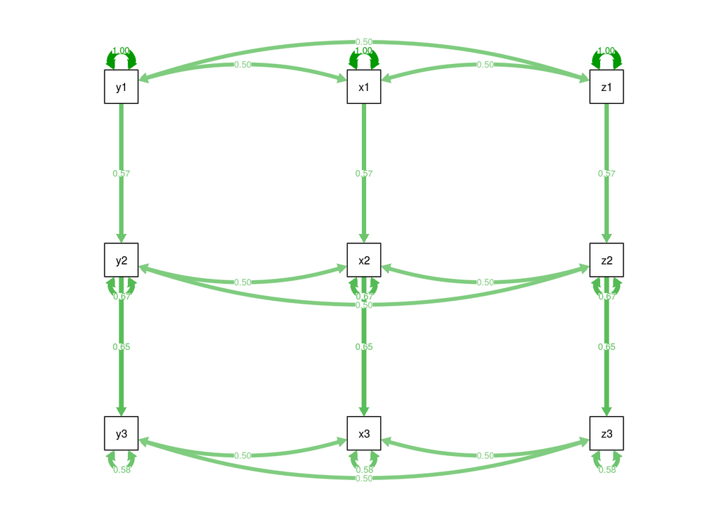

```r
semPaths(fit.DGM, what='std', layout = 'tree2')
```

Next, our best shot, controlling for the mediator and dependent variable at wave 1.

```r
summary(fit.CtrlT1.yz)
```

```
## lavaan (0.5-23.1097) converged normally after  12 iterations
##
##   Number of observations                           250
##
##   Estimator                                         ML
##   Minimum Function Test Statistic               19.721
##   Degrees of freedom                                 2
##   P-value (Chi-square)                           0.000
##
## Parameter Estimates:
##
##   Information                                 Expected
##   Standard Errors                             Standard
##
## Regressions:
##                    Estimate  Std.Err  z-value  P(>|z|)
##   y2 ~
##     y1                0.612    0.067    9.163    0.000
##     x1         (c)   -0.088    0.067   -1.317    0.188
##     z2         (b)    0.377    0.049    7.619    0.000
##   z2 ~
##     x1         (a)    0.000    0.073    0.000    1.000
##     z1                0.700    0.073    9.585    0.000
##
## Variances:
##                    Estimate  Std.Err  z-value  P(>|z|)
##    .y2                0.812    0.073   11.180    0.000
##    .z2                1.000    0.089   11.180    0.000
##
## Defined Parameters:
##                    Estimate  Std.Err  z-value  P(>|z|)
##     ab                0.000    0.028    0.000    1.000
##     total            -0.088    0.072   -1.217    0.224
```

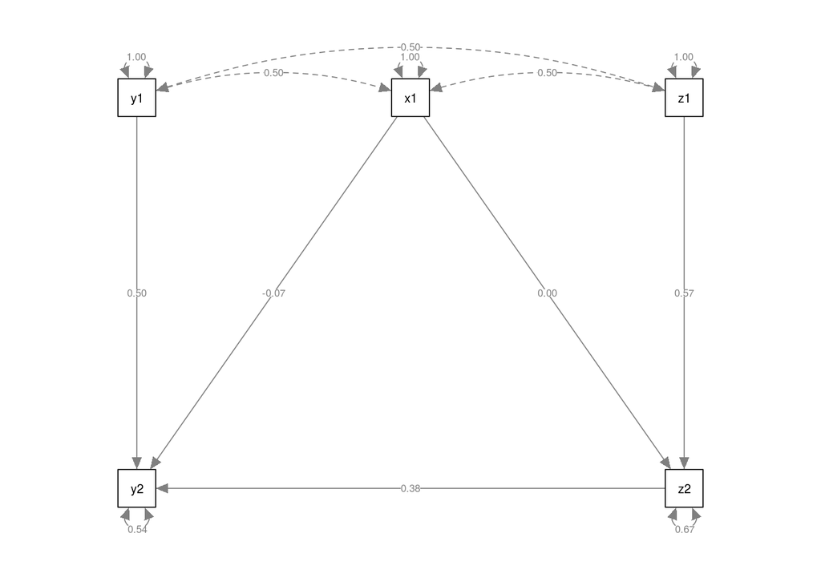

```r
semPaths(fit.CtrlT1.yz, whatLabels='std', layout = 'tree')
```

Now, progressively leaving things out….

```r
summary(fit.noCtrlT1.z)
```

```
## lavaan (0.5-23.1097) converged normally after  15 iterations
##
##   Number of observations                           250
##
##   Estimator                                         ML
##   Minimum Function Test Statistic                7.579
##   Degrees of freedom                                 1
##   P-value (Chi-square)                           0.006
##
## Parameter Estimates:
##
##   Information                                 Expected
##   Standard Errors                             Standard
##
## Regressions:
##                    Estimate  Std.Err  z-value  P(>|z|)
##   y2 ~
##     y1                0.612    0.066    9.303    0.000
##     x1         (c)   -0.088    0.068   -1.294    0.196
##     z2         (b)    0.377    0.049    7.735    0.000
##   z2 ~
##     x1         (a)    0.350    0.074    4.732    0.000
##
## Variances:
##                    Estimate  Std.Err  z-value  P(>|z|)
##    .y2                0.812    0.073   11.180    0.000
##    .z2                1.367    0.122   11.180    0.000
##
## Defined Parameters:
##                    Estimate  Std.Err  z-value  P(>|z|)
##     ab                0.132    0.033    4.037    0.000
##     total             0.044    0.071    0.615    0.538
```

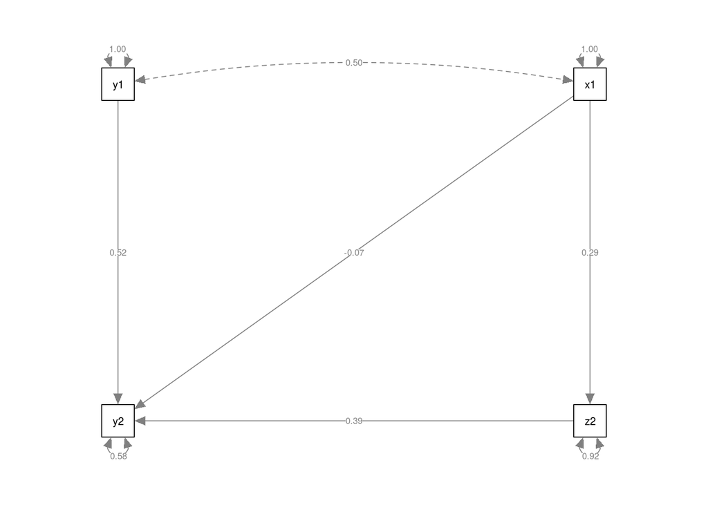

```r
semPaths(fit.noCtrlT1.z, whatLabels='std', layout = 'tree')
```

```r
summary(fit.noCtrlT1.yz)
```

```
## lavaan (0.5-23.1097) converged normally after  13 iterations
##
##   Number of observations                           250
##
##   Estimator                                         ML
##   Minimum Function Test Statistic                0.000
##   Degrees of freedom                                 0
##
## Parameter Estimates:
##
##   Information                                 Expected
##   Standard Errors                             Standard
##
## Regressions:
##                    Estimate  Std.Err  z-value  P(>|z|)
##   y2 ~
##     x1         (c)    0.191    0.069    2.774    0.006
##     z2         (b)    0.455    0.056    8.084    0.000
##   z2 ~
##     x1         (a)    0.350    0.074    4.732    0.000
##
## Variances:
##                    Estimate  Std.Err  z-value  P(>|z|)
##    .y2                1.084    0.097   11.180    0.000
##    .z2                1.367    0.122   11.180    0.000
##
## Defined Parameters:
##                    Estimate  Std.Err  z-value  P(>|z|)
##     ab                0.159    0.039    4.084    0.000
##     total             0.350    0.074    4.732    0.000
```

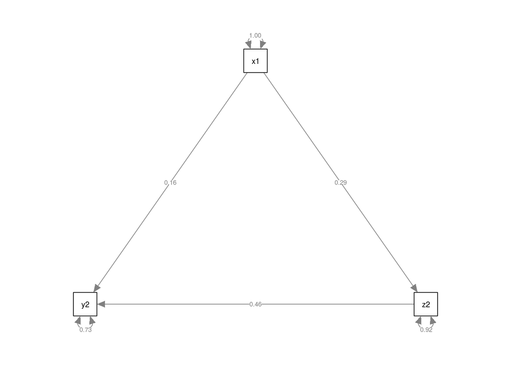

```r
semPaths(fit.noCtrlT1.yz, whatLabels='std', layout = 'tree')
```

```r
summary(fit.CrossSection)
```

```
## lavaan (0.5-23.1097) converged normally after  12 iterations
##
##   Number of observations                           250
##
##   Estimator                                         ML
##   Minimum Function Test Statistic                0.000
##   Degrees of freedom                                 0
##
## Parameter Estimates:
##
##   Information                                 Expected
##   Standard Errors                             Standard
##
## Regressions:
##                    Estimate  Std.Err  z-value  P(>|z|)
##   y3 ~
##     x3         (c)    0.333    0.060    5.590    0.000
##     z3         (b)    0.333    0.060    5.590    0.000
##   z3 ~
##     x3         (a)    0.500    0.055    9.129    0.000
##
## Variances:
##                    Estimate  Std.Err  z-value  P(>|z|)
##    .y3                1.153    0.103   11.180    0.000
##    .z3                1.298    0.116   11.180    0.000
##
## Defined Parameters:
##                    Estimate  Std.Err  z-value  P(>|z|)
##     ab                0.167    0.035    4.767    0.000
##     total             0.500    0.055    9.129    0.000
```

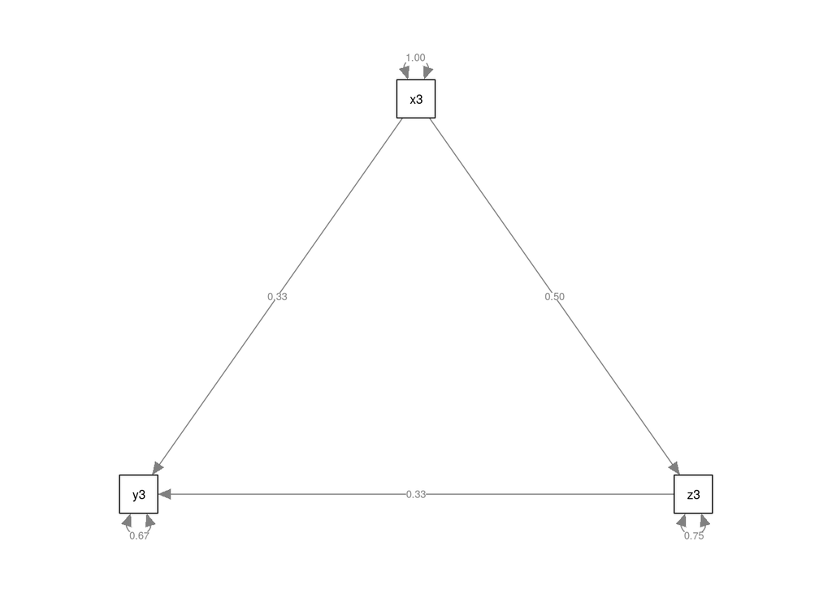

```r
semPaths(fit.CrossSection, whatLabels='std', layout = 'tree')
```

```r
summary(fit.BadLong)
```

```
## lavaan (0.5-23.1097) converged normally after  15 iterations
##
##   Number of observations                           250
##
##   Estimator                                         ML
##   Minimum Function Test Statistic                0.000
##   Degrees of freedom                                 0
##   Minimum Function Value               0.0000000000000
##
## Parameter Estimates:
##
##   Information                                 Expected
##   Standard Errors                             Standard
##
## Regressions:
##                    Estimate  Std.Err  z-value  P(>|z|)
##   y3 ~
##     x1         (c)    0.133    0.082    1.634    0.102
##     z2         (b)    0.319    0.067    4.761    0.000
##   z2 ~
##     x1         (a)    0.350    0.074    4.732    0.000
##
## Variances:
##                    Estimate  Std.Err  z-value  P(>|z|)
##    .y3                1.531    0.137   11.180    0.000
##    .z2                1.368    0.122   11.180    0.000
##
## Defined Parameters:
##                    Estimate  Std.Err  z-value  P(>|z|)
##     ab                0.112    0.033    3.356    0.001
##     total             0.245    0.082    2.998    0.003
```

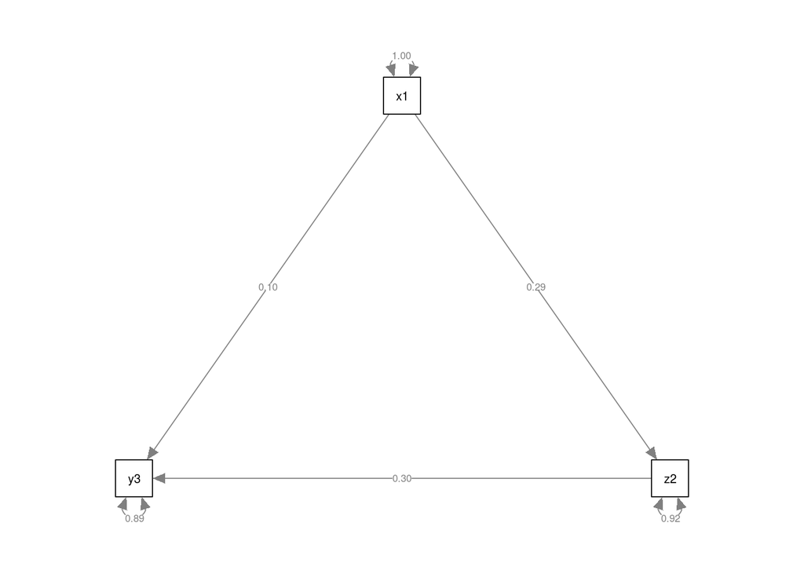

```r
semPaths(fit.BadLong, whatLabels='std', layout = 'tree')
```

## Power to detect mediation (when the null is true)

You can see that we’re getting a hint that the `ab` path might be getting bigger as we further misspecify the model. To find out for sure, let’s run the simulations. Our outcome of interest will be the measure of power to detect a significant `ab` path – the mediated effect. Usually power is a good thing, but if you have power to detect something that’s not there, it’s an indication that your model is reliably giving you the wrong answer.

```r
REDOSIMS=F
if(REDOSIMS){
    sim.CtrlT1.yz <- simsem::sim(nRep=1000,
                                 model=mediationModelControlzT1,
                                 n=250,
                                 generate=generatingModel,
                                 lavaanfun="sem",
                                 std.lv=F,
                                 multicore=T)
    sim.noCtrlT1.z <- simsem::sim(nRep=1000,
                                  model=mediationModelNoControlzT1,
                                  n=250,
                                  generate=generatingModel,
                                  lavaanfun="sem",
                                  std.lv=F,
                                  multicore=T)
    sim.noCtrlT1.yz <- simsem::sim(nRep=1000,
                                   model=mediationModelNoControlzOryT1,
                                   n=250,
                                   generate=generatingModel,
                                   lavaanfun="sem",
                                   std.lv=F,
                                   multicore=T)
    sim.CrossSection <- simsem::sim(nRep=1000,
                                   model=mediationModelCrossSection,
                                   n=250,
                                   generate=generatingModel,
                                   lavaanfun="sem",
                                   std.lv=F,
                                   multicore=T)
    sim.BadLong <- simsem::sim(nRep=1000,
                                   model=mediationBadLong,
                                   n=250,
                                   generate=generatingModel,
                                   lavaanfun="sem",
                                   std.lv=F,
                                   multicore=T)
    saveRDS(object=sim.CtrlT1.yz, file='sim_CtrlT1_yz.RDS')
    saveRDS(object=sim.noCtrlT1.z, file='sim_noCtrlT1_z.RDS')
    saveRDS(object=sim.noCtrlT1.yz, file='sim_noCtrlT1_yz.RDS')
    saveRDS(object=sim.CrossSection, file='sim_CrossSection.RDS')
    saveRDS(object=sim.BadLong, file='sim_BadLong.RDS')
} else {
    sim.CtrlT1.yz <- readRDS(file='sim_CtrlT1_yz.RDS')
    sim.noCtrlT1.z <- readRDS(file='sim_noCtrlT1_z.RDS')
    sim.noCtrlT1.yz <- readRDS(file='sim_noCtrlT1_yz.RDS')
    sim.CrossSection <- readRDS(file='sim_CrossSection.RDS')
    sim.BadLong <- readRDS(file='sim_BadLong.RDS')
}
```

```r
knitr::kable(summaryParam(sim.CtrlT1.yz), digits=2)
```

|  | Estimate Average | Estimate SD | Average SE | Power (Not equal 0) | Std Est | Std Est SD | Std Ave SE |
| --- | --- | --- | --- | --- | --- | --- | --- |
| y2~y1 | 0.61 | 0.07 | 0.07 | 1.00 | 0.50 | 0.05 | 0.05 |
| c | -0.09 | 0.07 | 0.07 | 0.26 | -0.07 | 0.06 | 0.05 |
| b | 0.38 | 0.05 | 0.05 | 1.00 | 0.38 | 0.05 | 0.05 |
| a | 0.00 | 0.07 | 0.07 | 0.06 | 0.00 | 0.06 | 0.06 |
| z2~z1 | 0.70 | 0.07 | 0.07 | 1.00 | 0.58 | 0.05 | 0.05 |
| y2~~y2 | 0.80 | 0.07 | 0.07 | 1.00 | 0.54 | 0.04 | 0.04 |
| z2~~z2 | 0.98 | 0.09 | 0.09 | 1.00 | 0.66 | 0.05 | 0.04 |
| ab | 0.00 | 0.03 | 0.03 | 0.05 | 0.00 | 0.02 | 0.02 |
| total | -0.09 | 0.08 | 0.07 | 0.25 | -0.07 | 0.06 | 0.06 |

```r
knitr::kable(summaryParam(sim.noCtrlT1.z), digits=2)
```

|  | Estimate Average | Estimate SD | Average SE | Power (Not equal 0) | Std Est | Std Est SD | Std Ave SE |
| --- | --- | --- | --- | --- | --- | --- | --- |
| y2~y1 | 0.61 | 0.07 | 0.07 | 1.00 | 0.51 | 0.05 | 0.05 |
| c | -0.09 | 0.07 | 0.07 | 0.25 | -0.07 | 0.06 | 0.06 |
| b | 0.38 | 0.05 | 0.05 | 1.00 | 0.39 | 0.05 | 0.05 |
| a | 0.35 | 0.07 | 0.07 | 1.00 | 0.28 | 0.06 | 0.06 |
| y2~~y2 | 0.80 | 0.07 | 0.07 | 1.00 | 0.57 | 0.04 | 0.04 |
| z2~~z2 | 1.36 | 0.13 | 0.12 | 1.00 | 0.92 | 0.03 | 0.03 |
| ab | 0.13 | 0.03 | 0.03 | 0.99 | 0.11 | 0.03 | 0.03 |
| total | 0.05 | 0.07 | 0.07 | 0.11 | 0.04 | 0.06 | 0.06 |

```r
knitr::kable(summaryParam(sim.noCtrlT1.yz), digits=2)
```

|  | Estimate Average | Estimate SD | Average SE | Power (Not equal 0) | Std Est | Std Est SD | Std Ave SE |
| --- | --- | --- | --- | --- | --- | --- | --- |
| c | 0.19 | 0.07 | 0.07 | 0.79 | 0.16 | 0.06 | 0.06 |
| b | 0.46 | 0.06 | 0.06 | 1.00 | 0.45 | 0.05 | 0.05 |
| a | 0.35 | 0.07 | 0.07 | 1.00 | 0.29 | 0.06 | 0.06 |
| y2~~y2 | 1.07 | 0.09 | 0.10 | 1.00 | 0.72 | 0.05 | 0.05 |
| z2~~z2 | 1.36 | 0.13 | 0.12 | 1.00 | 0.92 | 0.03 | 0.03 |
| ab | 0.16 | 0.04 | 0.04 | 0.99 | 0.13 | 0.03 | 0.03 |
| total | 0.35 | 0.08 | 0.07 | 0.99 | 0.29 | 0.06 | 0.06 |

```r
knitr::kable(summaryParam(sim.CrossSection), digits=2)
```

|  | Estimate Average | Estimate SD | Average SE | Power (Not equal 0) | Std Est | Std Est SD | Std Ave SE |
| --- | --- | --- | --- | --- | --- | --- | --- |
| c | 0.34 | 0.06 | 0.06 | 1 | 0.34 | 0.06 | 0.06 |
| b | 0.33 | 0.06 | 0.06 | 1 | 0.33 | 0.06 | 0.06 |
| a | 0.50 | 0.06 | 0.05 | 1 | 0.50 | 0.05 | 0.04 |
| y3~~y3 | 1.14 | 0.10 | 0.10 | 1 | 0.66 | 0.05 | 0.05 |
| z3~~z3 | 1.29 | 0.12 | 0.12 | 1 | 0.75 | 0.05 | 0.04 |
| ab | 0.16 | 0.03 | 0.04 | 1 | 0.16 | 0.03 | 0.03 |
| total | 0.50 | 0.05 | 0.05 | 1 | 0.50 | 0.05 | 0.04 |

```r
knitr::kable(summaryParam(sim.BadLong), digits=2)
```

|  | Estimate Average | Estimate SD | Average SE | Power (Not equal 0) | Std Est | Std Est SD | Std Ave SE |
| --- | --- | --- | --- | --- | --- | --- | --- |
| c | 0.14 | 0.08 | 0.08 | 0.38 | 0.10 | 0.06 | 0.06 |
| b | 0.32 | 0.07 | 0.07 | 0.99 | 0.29 | 0.06 | 0.06 |
| a | 0.35 | 0.07 | 0.07 | 1.00 | 0.29 | 0.06 | 0.06 |
| y3~~y3 | 1.51 | 0.14 | 0.14 | 1.00 | 0.88 | 0.04 | 0.04 |
| z2~~z2 | 1.36 | 0.13 | 0.12 | 1.00 | 0.92 | 0.03 | 0.03 |
| ab | 0.11 | 0.03 | 0.03 | 0.98 | 0.08 | 0.02 | 0.02 |
| total | 0.25 | 0.08 | 0.08 | 0.86 | 0.19 | 0.06 | 0.06 |

Looking across those `ab` lines, you see that we’re not too bad off if we control for our wave 1 measurements. However, if we don’t do that, we end up with massive power to detect a significant mediation. To me, this warrants extreme caution.

## Mediation package?

There’s a cool package called `mediation` written by some experts in causal inference. I’ve used it in a paper. I only controlled for the previous level of the outcome variable. Does this package’s machinations obviate any of the issues with causal inference in mediation illustrated above? Let’s find out!

```r
library(mediation)

crosssectionMediateModel <- function(aDF){
    model.m <- lm(z2 ~ x2, data = aDF)
    model.y <- lm(y2 ~ x2 + z2, data = aDF)

    mediateModel <- try(mediate(model.m = model.m, model.y = model.y,
                            sims = 500, boot = F,
                            treat = 'x2', mediator = 'z2'))
    if (identical(class(mediateModel), "try-error")){
        rezlist <- list(coef = NA, se = NA, converged = FALSE)
    } else {
        coefVec <- c(d0 = mediateModel$d0, d1 = mediateModel$d0,
                     z0 = mediateModel$z0, z1 = mediateModel$d0,
                     n0 = mediateModel$n0, n1 = mediateModel$n0)

        seVec <- c(d0 = NA, d1 = NA,
                   z0 = NA, z1 = NA,
                   n0 = NA, n1 = NA)

        cilowerVec <- c(d0 = mediateModel$d0.ci[[1]], d1 = mediateModel$d0.ci[[1]],
                        z0 = mediateModel$z0.ci[[1]], z1 = mediateModel$d0.ci[[1]],
                        n0 = mediateModel$n0.ci[[1]], n1 = mediateModel$n0.ci[[1]])

        ciupperVec <- c(d0 = mediateModel$d0.ci[[2]], d1 = mediateModel$d0.ci[[2]],
                        z0 = mediateModel$z0.ci[[2]], z1 = mediateModel$d0.ci[[2]],
                        n0 = mediateModel$n0.ci[[2]], n1 = mediateModel$n0.ci[[2]])

        rezList <- list(coef = coefVec, se = seVec, cilower = cilowerVec, ciupper = ciupperVec, converged = TRUE)
    }

    return(rezList)
}

anOutfun <- function(obj){
    acmeNotZero <- !(all(obj$ciupper['d0'] >= 0, obj$cilower['d0'] <= 0))
}

if(REDOSIMS){
    mediatePkgCrossSection <- simsem::sim(nRep = 8*10, n = 200, generate = generatingModel,
                                          model = crosssectionMediateModel,
                                          multicore = TRUE, outfun = anOutfun)
    saveRDS(mediatePkgCrossSection, 'mediatePkgCrossSection.RDS')
} else {
    mediatePkgCrossSection <- readRDS('mediatePkgCrossSection.RDS')
}
summary(mediatePkgCrossSection)
```

```
## RESULT OBJECT
## Model Type
## [1] "function"
## ========= Parameter Estimates and Standard Errors ============
##    Estimate Average Estimate SD
## d0            0.167       0.035
## d1            0.167       0.035
## z0            0.328       0.064
## z1            0.167       0.035
## n0            0.339       0.075
## n1            0.339       0.075
## ================== Replications =====================
## Number of replications = 80
## Number of converged replications = 80
## Number of nonconverged replications:
##    1. Nonconvergent Results = 0
##    2. Nonconvergent results from multiple imputation = 0
##    3. At least one SE were negative or NA = 0
##    4. At least one variance estimates were negative = 0
##    5. At least one correlation estimates were greater than 1 or less than -1 = 0
##    6. Model-implied covariance matrices of any groups of latent variables are not positive definite = 0
## NOTE: The data generation model is not the same as the analysis model. See the summary of the population underlying data generation by the summaryPopulation function.
```

```r
cat(paste0("Proportion of simulations that reject null of no mediation: ",
           mediationPower <- sum(unlist(getExtraOutput(mediatePkgCrossSection)))/mediatePkgCrossSection@nRep))
```

```
## Proportion of simulations that reject null of no mediation: 1
```

So using this package doesn’t help at all in cross-sectional data. We can examine the case with appropriate controls for previous levels as well, to make sure that this may help across techniques.

```r
controlPrevWaveMediateModel <- function(aDF){
    model.m <- lm(z2 ~ z1 + x1, data = aDF)
    model.y <- lm(y2 ~ y1 + x1 + z2, data = aDF)

    mediateModel <- try(mediate(model.m = model.m, model.y = model.y,
                            sims = 500, boot = F,
                            treat = 'x1', mediator = 'z2'))
    if (identical(class(mediateModel), "try-error")){
        rezlist <- list(coef = NA, se = NA, converged = FALSE)
    } else {
        coefVec <- c(d0 = mediateModel$d0, d1 = mediateModel$d0,
                     z0 = mediateModel$z0, z1 = mediateModel$d0,
                     n0 = mediateModel$n0, n1 = mediateModel$n0)

        seVec <- c(d0 = NA, d1 = NA,
                   z0 = NA, z1 = NA,
                   n0 = NA, n1 = NA)

        cilowerVec <- c(d0 = mediateModel$d0.ci[[1]], d1 = mediateModel$d0.ci[[1]],
                        z0 = mediateModel$z0.ci[[1]], z1 = mediateModel$d0.ci[[1]],
                        n0 = mediateModel$n0.ci[[1]], n1 = mediateModel$n0.ci[[1]])

        ciupperVec <- c(d0 = mediateModel$d0.ci[[2]], d1 = mediateModel$d0.ci[[2]],
                        z0 = mediateModel$z0.ci[[2]], z1 = mediateModel$d0.ci[[2]],
                        n0 = mediateModel$n0.ci[[2]], n1 = mediateModel$n0.ci[[2]])

        rezList <- list(coef = coefVec, se = seVec, cilower = cilowerVec, ciupper = ciupperVec, converged = TRUE)
    }

    return(rezList)
}

if(REDOSIMS){
    mediatePkgControlPrev <- simsem::sim(nRep = 8*10, n = 200, generate = generatingModel,
                                          model = controlPrevWaveMediateModel,
                                          multicore = TRUE, outfun = anOutfun)
    saveRDS(mediatePkgControlPrev, 'mediatePkgControlPrev.RDS')
} else {
    mediatePkgControlPrev <- readRDS('mediatePkgControlPrev.RDS')
}
summary(mediatePkgControlPrev)
```

```
## RESULT OBJECT
## Model Type
## [1] "function"
## ========= Parameter Estimates and Standard Errors ============
##    Estimate Average Estimate SD
## d0           -0.001       0.031
## d1           -0.001       0.031
## z0           -0.099       0.078
## z1           -0.001       0.031
## n0            0.109       0.177
## n1            0.109       0.177
## ================== Replications =====================
## Number of replications = 80
## Number of converged replications = 80
## Number of nonconverged replications:
##    1. Nonconvergent Results = 0
##    2. Nonconvergent results from multiple imputation = 0
##    3. At least one SE were negative or NA = 0
##    4. At least one variance estimates were negative = 0
##    5. At least one correlation estimates were greater than 1 or less than -1 = 0
##    6. Model-implied covariance matrices of any groups of latent variables are not positive definite = 0
## NOTE: The data generation model is not the same as the analysis model. See the summary of the population underlying data generation by the summaryPopulation function.
```

```r
cat(paste0("Proportion of simulations that reject null of no mediation: ",
           mediationPower <- sum(unlist(getExtraOutput(mediatePkgControlPrev)))/mediatePkgControlPrev@nRep))
```

```
## Proportion of simulations that reject null of no mediation: 0.0625
```

This should be around .05, which is the false-positive rate we expect (this is a small number of simulations, 80, so it easily could be a bit above or below).

## Conclusion

Using the two most common methods I’ve seen to assess mediation (path-tracing, or the `mediation` package), cross-sectional data will produce evidence of mediation when there is no actual mediation. We know there is no actual mediation because we’ve created the data such that each variable is only conditional on its previous level, and not at all on the measurements of the other variables.

For further reading about mediation as one of a family of causal claims, check out

> Bullock, J. G., Green, D. P., & Ha, S. E. (2010). Yes, but what’s the mechanism? (don’t expect an easy answer). Journal of Personality and Social Psychology, 98(4), 550–558. http://doi.org/10.1037/a0018933